# Fraud Detection

Ashley (Shiyi) Yue

2023-03-21

## Predicting Probability of Default 35 pts

```r
# Load the data
rm(list = ls())

library(readr)
train_ds <- read_csv("loan_train_final.csv")
test_ds <- read_csv("loan_test_final.csv")
# Explore the data set
str(train_ds)
```

```
## spc_tbl_ [2,400 × 31] (S3: spec_tbl_df/tbl_df/tbl/data.frame)
##  $ default            : num [1:2400] 0 1 1 1 1 1 1 0 0 0 ...
##  $ n_collect          : num [1:2400] 0 0 0 0 0 0 0 0 0 0 ...
##  $ credit_ratio       : num [1:2400] 82.7 86.1 51.6 52.3 41.1 99 22.4 94.3 68.1 78.7 ...
##  $ interest           : num [1:2400] 14.5 17.6 16.2 20.9 14.6 ...
##  $ initial_list_status: chr [1:2400] "a" "a" "a" "a" ...
##  $ recover            : num [1:2400] 0 0 2016 453 0 ...
##  $ coll_fee           : num [1:2400] 0 0 362.89 4.98 0 ...
##  $ out_prncp          : num [1:2400] 11815 8148 0 0 18832 ...
##  $ total_cc           : num [1:2400] 16347 1274 10772 9523 2344 ...
##  $ term               : chr [1:2400] "3 yrs" "3 yrs" "5 yrs" "5 yrs" ...
##  $ fees_rec           : num [1:2400] 0 0 0 0 0 0 0 0 0 0 ...
##  $ total_acc          : num [1:2400] 18 19 23 51 34 31 35 23 20 23 ...
##  $ employment         : chr [1:2400] "10+" NA "< 1" "4" ...
##  $ amount             : num [1:2400] 23725 8925 27575 24000 20000 ...
##  $ monthly_payment    : num [1:2400] 817 321 674 454 472 ...
##  $ funded             : num [1:2400] 23725 8925 27575 16800 20000 ...
##  $ status             : chr [1:2400] "partial" "checked" "partial" "checked" ...
##  $ v1                 : num [1:2400] 13.6 24.5 27.5 22.9 34.3 ...
##  $ int_rec            : num [1:2400] 4437 497 4506 5269 1176 ...
##  $ reason             : chr [1:2400] "debt" "debt" "debt" "debt" ...
##  $ last_payment       : num [1:2400] 816.5 320.7 673.5 26.4 472.1 ...
##  $ pymnt_rec          : num [1:2400] 16347 1231 10772 9523 2344 ...
##  $ quality            : chr [1:2400] "q3" "q4" "q3" "q7" ...
##  $ out_prncp_inv      : num [1:2400] 11815 7874 0 0 18832 ...
##  $ violations         : num [1:2400] 1 0 0 0 0 0 0 0 0 0 ...
##  $ del                : num [1:2400] 0 4 0 0 0 0 0 0 0 0 ...
##  $ inc                : num [1:2400] 112000 40000 62000 136000 53000 ...
##  $ prin_rec           : num [1:2400] 11910 777 4250 3801 1168 ...
##  $ credit_bal         : num [1:2400] 18121 4046 13827 9149 20582 ...
##  $ ncc                : num [1:2400] 9 7 10 20 21 3 24 14 6 11 ...
##  $ req                : num [1:2400] 1 0 0 5 3 1 0 0 1 2 ...
##  - attr(*, "spec")=
##   .. cols(
##   ..   default = col_double(),
##   ..   n_collect = col_double(),
##   ..   credit_ratio = col_double(),
##   ..   interest = col_double(),
##   ..   initial_list_status = col_character(),
##   ..   recover = col_double(),
```

[output cut: 12 more lines]

```
##   ..   int_rec = col_double(),
##   ..   reason = col_character(),
##   ..   last_payment = col_double(),
##   ..   pymnt_rec = col_double(),
##   ..   quality = col_character(),
##   ..   out_prncp_inv = col_double(),
##   ..   violations = col_double(),
##   ..   del = col_double(),
##   ..   inc = col_double(),
##   ..   prin_rec = col_double(),
##   ..   credit_bal = col_double(),
##   ..   ncc = col_double(),
##   ..   req = col_double()
##   .. )
##  - attr(*, "problems")=<externalptr>
```

```r
# Subset the dataframe into numeric columns and character columns for further study
train_num <- train_ds[,sapply(train_ds, is.numeric)]
train_chr <- train_ds[,sapply(train_ds, is.character)]
```

```r
# Check for unique values for each character attribute
sapply(train_chr,unique)
```

```
## $initial_list_status
## [1] "a" "b"
##
## $term
## [1] "3 yrs" "5 yrs"
##
## $employment
##  [1] "10+" NA    "< 1" "4"   "7"   "1"   "3"   "6"   "2"   "8"   "5"   "9"
##
## $status
## [1] "partial"   "checked"   "unchecked"
##
## $reason
##  [1] "debt"       "renovation" "cc"         "business"   "boat"
##  [6] "other"      "moving"     "holiday"    "medical"    "transport"
## [11] "home"       "event"      "solar"
##
## $quality
## [1] "q3" "q4" "q7" "q2" "q1" "q5" "q6"
```

All the character variables seem good to be converted to factor variables except employment.

```r
summary(as.factor(train_ds$employment))
```

```
##  < 1    1  10+    2    3    4    5    6    7    8    9 NA's
##  199  146  730  208  206  163  142  122  134  110  106  134
```

Merge employment less than 4 as a factor ([0,3]), greater than 3 and less than 10 as a factor ([4,9]), greater than 10 as a factor ([10,]). Set NAs as the middle group ([4,9])

```r
train_ds$employment <- ifelse((train_ds$employment %in% c("< 1","1","2","3")), "< 4", train_ds$employment)
train_ds$employment <- ifelse((train_ds$employment %in% c("4","5","6","7","8","9")), "< 9", train_ds$employment)
train_ds$employment <- ifelse(is.na(train_ds$employment), "< 9", train_ds$employment)
train_ds$employment <- as.factor(train_ds$employment)

test_ds$employment <- ifelse((test_ds$employment %in% c("< 1","1","2","3")), "< 4", test_ds$employment)
test_ds$employment <- ifelse((test_ds$employment %in% c("4","5","6","7","8","9")), "< 9", test_ds$employment)
test_ds$employment <- ifelse(is.na(test_ds$employment), "< 9", test_ds$employment)
test_ds$employment <- as.factor(test_ds$employment)

summary(train_ds$employment)
```

```
## < 4 < 9 10+
## 759 911 730
```

```r
# Convert character variables into factor variables
for (i in colnames(train_chr)) {
  train_ds[[i]] <- as.factor(train_ds[[i]])
  test_ds[[i]] <- as.factor(test_ds[[i]])
}
```

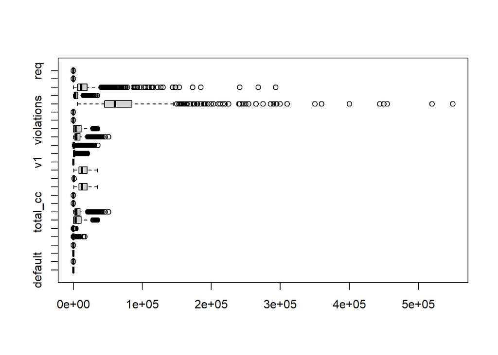

```r
# Boxplot numeric variables to examine outliers
boxplot(train_num, horizontal = T)
```

The scales of variables vary heavily. Standardization may be necessary.

```r
# Exclude default from numeric variable list
train_num <- train_num[,-1]

# Scale the numeric variables
for (i in colnames(train_num)) {
  train_ds[[i]] <- as.vector(scale(train_ds[[i]]))
  train_ds[[i]]
  test_ds[[i]] <- as.vector(scale(test_ds[[i]]))
}
```

```r
# Check if there is NA value
summary(train_num)
```

```
##    n_collect        credit_ratio       interest        recover
##  Min.   :0.00000   Min.   :  0.00   Min.   : 5.32   Min.   :    0.0
##  1st Qu.:0.00000   1st Qu.: 37.77   1st Qu.:10.99   1st Qu.:    0.0
##  Median :0.00000   Median : 57.40   Median :13.98   Median :    0.0
##  Mean   :0.01167   Mean   : 55.78   Mean   :14.11   Mean   :  235.6
##  3rd Qu.:0.00000   3rd Qu.: 74.83   3rd Qu.:16.99   3rd Qu.:    0.0
##  Max.   :1.00000   Max.   :108.50   Max.   :28.99   Max.   :16794.7
##     coll_fee         out_prncp        total_cc        fees_rec
##  Min.   :   0.00   Min.   :    0   Min.   :    0   Min.   :  0.0000
##  1st Qu.:   0.00   1st Qu.:    0   1st Qu.: 2075   1st Qu.:  0.0000
##  Median :   0.00   Median : 3182   Median : 4587   Median :  0.0000
##  Mean   :  25.67   Mean   : 6647   Mean   : 7168   Mean   :  0.9274
##  3rd Qu.:   0.00   3rd Qu.:11461   3rd Qu.: 9682   3rd Qu.:  0.0000
##  Max.   :3703.43   Max.   :35000   Max.   :51039   Max.   :102.5000
##    total_acc         amount      monthly_payment      funded
##  Min.   : 3.00   Min.   :  800   Min.   :  25.8   Min.   :  800
##  1st Qu.:16.00   1st Qu.: 8000   1st Qu.: 254.5   1st Qu.: 8000
##  Median :23.00   Median :12675   Median : 385.8   Median :12650
##  Mean   :25.15   Mean   :14498   Mean   : 436.0   Mean   :14482
##  3rd Qu.:32.00   3rd Qu.:20000   3rd Qu.: 565.1   3rd Qu.:20000
##  Max.   :87.00   Max.   :35000   Max.   :1343.9   Max.   :35000
##        v1           int_rec         last_payment       pymnt_rec
##  Min.   : 0.00   Min.   :    0.0   Min.   :    0.0   Min.   :    0
##  1st Qu.:11.85   1st Qu.:  478.4   1st Qu.:  263.2   1st Qu.: 2056
##  Median :17.95   Median : 1151.8   Median :  429.0   Median : 4519
##  Mean   :18.20   Mean   : 1853.6   Mean   : 1688.7   Mean   : 7110
##  3rd Qu.:24.13   3rd Qu.: 2333.1   3rd Qu.:  723.9   3rd Qu.: 9560
##  Max.   :39.64   Max.   :20295.8   Max.   :35680.2   Max.   :51039
##  out_prncp_inv     violations           del             inc
##  Min.   :    0   Min.   : 0.0000   Min.   : 0.00   Min.   :  6000
##  1st Qu.:    0   1st Qu.: 0.0000   1st Qu.: 0.00   1st Qu.: 45000
##  Median : 3182   Median : 0.0000   Median : 0.00   Median : 60430
##  Mean   : 6644   Mean   : 0.1854   Mean   : 0.35   Mean   : 71828
##  3rd Qu.:11445   3rd Qu.: 0.0000   3rd Qu.: 0.00   3rd Qu.: 85000
##  Max.   :35000   Max.   :15.0000   Max.   :14.00   Max.   :550000
##     prin_rec       credit_bal          ncc             req
##  Min.   :    0   Min.   :     0   Min.   : 1.00   Min.   : 0.0000
##  1st Qu.: 1153   1st Qu.:  6201   1st Qu.: 8.00   1st Qu.: 0.0000
##  Median : 2828   Median : 11444   Median :11.00   Median : 0.0000
##  Mean   : 5077   Mean   : 15963   Mean   :11.54   Mean   : 0.8429
##  3rd Qu.: 6509   3rd Qu.: 19737   3rd Qu.:14.00   3rd Qu.: 1.0000
##  Max.   :35000   Max.   :293270   Max.   :40.00   Max.   :12.0000
```

There is no NA value for numeric variables.

```r
library(caret)
# Convert "default" into factor variable
train_ds$default <- as.factor(train_ds$default)
test_ds$default <- as.factor(test_ds$default)

# Check predictors with low variation
nearZeroVar(train_ds, names = T)
```

```
## [1] "n_collect" "fees_rec"
```

```r
nearZeroVar(test_ds, names = T)
```

```
## [1] "n_collect" "fees_rec"
```

The two variables above are of low variance in both the training and the testing set. So we exclude them from the model.

```r
# Filter out predictors with very low variance
train_ds <- train_ds[,-nearZeroVar(train_ds)]
test_ds <- test_ds[,-nearZeroVar(test_ds)]
```

```r
# Check distribution of Y variable
table(train_ds$default)
```

```
##
##    0    1
## 1598  802
```

```r
# Fit a plain logistic regression model
model <- glm(default ~ ., family = "binomial", data = train_ds)
summary(model)
```

```
##
## Call:
## glm(formula = default ~ ., family = "binomial", data = train_ds)
##
## Deviance Residuals:
##     Min       1Q   Median       3Q      Max
## -2.5765  -0.4313  -0.2691   0.0000   4.4631
##
## Coefficients:
##                        Estimate Std. Error z value Pr(>|z|)
## (Intercept)           9.976e+01  8.512e+02   0.117 0.906697
## credit_ratio          1.287e-01  9.717e-02   1.324 0.185362
## interest              8.978e-01  3.359e-01   2.673 0.007515 **
## initial_list_statusb -1.558e-01  1.790e-01  -0.870 0.384030
## recover              -8.213e+01  5.958e+02  -0.138 0.890354
## coll_fee              5.860e+01  2.654e+03   0.022 0.982383
## out_prncp            -2.862e+02  2.014e+03  -0.142 0.887013
## total_cc              3.425e+02  1.356e+02   2.525 0.011571 *
## term5 yrs             3.856e-01  4.495e-01   0.858 0.390934
## total_acc             5.834e-02  1.185e-01   0.492 0.622502
## employment< 9         2.504e-01  2.008e-01   1.247 0.212442
## employment10+        -4.693e-02  2.216e-01  -0.212 0.832266
## amount               -3.422e+02  2.672e+05  -0.001 0.998978
## monthly_payment       7.328e-01  5.730e-01   1.279 0.200958
## funded                6.484e+02  2.669e+05   0.002 0.998062
## statuspartial         4.397e-01  1.977e-01   2.224 0.026133 *
## statusunchecked       1.523e-01  2.438e-01   0.624 0.532348
## v1                   -1.026e-01  9.600e-02  -1.069 0.285239
## int_rec              -1.286e+02  3.490e+01  -3.685 0.000228 ***
## reasonbusiness        8.147e-01  9.065e-01   0.899 0.368810
## reasoncc             -1.624e-01  6.731e-01  -0.241 0.809388
## reasondebt            1.714e-01  6.464e-01   0.265 0.790854
## reasonevent          -2.142e+01  1.678e+05   0.000 0.999898
## reasonholiday        -1.736e+01  3.405e+03  -0.005 0.995931
## reasonhome            2.670e+00  1.565e+00   1.706 0.087982 .
## reasonmedical         5.822e-01  1.083e+00   0.538 0.590868
## reasonmoving          4.402e-01  9.802e-01   0.449 0.653394
## reasonother           1.056e-01  7.158e-01   0.148 0.882658
## reasonrenovation      5.551e-01  7.024e-01   0.790 0.429418
## reasonsolar          -2.182e+01  9.215e+04   0.000 0.999811
```

[output cut: 12 more lines]

```
## inc                  -9.144e-02  1.109e-01  -0.824 0.409772
## prin_rec             -5.685e+02  1.499e+03  -0.379 0.704424
## credit_bal           -9.165e-02  1.172e-01  -0.782 0.434271
## ncc                   3.051e-02  1.184e-01   0.258 0.796739
## req                   1.715e-01  9.339e-02   1.836 0.066356 .
## ---
## Signif. codes:  0 '***' 0.001 '**' 0.01 '*' 0.05 '.' 0.1 ' ' 1
##
## (Dispersion parameter for binomial family taken to be 1)
##
##     Null deviance: 3058.0  on 2399  degrees of freedom
## Residual deviance: 1030.3  on 2353  degrees of freedom
## AIC: 1124.3
##
## Number of Fisher Scoring iterations: 23
```

```r
library(rfUtilities)
y_test <- as.numeric(test_ds$default)-1
y_hat <- predict(model, test_ds, type = "response")
y_hat_cali <- probability.calibration(y_test, y_hat, regularization = T)
MAE <- mean(abs(y_test - y_hat_cali))
MAE
```

```
## [1] 0.1207333
```

There are many insignificant predictors. Consider performing lasso regression to do feature selection.

```r
# Convert categorical variables to dummies
library(fastDummies)
train_ds_dm <- dummy_cols(train_ds, select_columns = colnames(train_chr), remove_selected_columns = T, remove_first_dummy = T)
test_ds_dm <- dummy_cols(test_ds, select_columns = colnames(train_chr), remove_selected_columns = T, remove_first_dummy = T)
```

```r
library(glmnet)
set.seed(117)

X_train <- as.matrix(train_ds_dm[,-1])
y_train <- as.numeric(train_ds$default) - 1
X_test <- as.matrix(test_ds_dm[,-1])
y_test <- as.numeric(test_ds$default) - 1

# Specify penalty factor to unpenalize dummy variables
n_num <- 22
n_dum <- ncol(X_train) - n_num
factor <- c(rep(1,n_num), rep(0,n_dum))

# Fit a lasso regression model with cross-validation
cv.lasso <- cv.glmnet(X_train, y_train, penalty.factor=factor, family="binomial", alpha = 1)

# Fit lasso regression model with min lambda and 1se lambda
lasso_1se_mod <- glmnet(X_train, y_train, penalty.factor=factor, family="binomial", alpha = 1, lambda = cv.lasso$lambda.1se)
lasso_min_mod <- glmnet(X_train, y_train, penalty.factor=factor, family="binomial", alpha = 1, lambda = cv.lasso$lambda.min)
```

```r
# Predict y_hat
y.hat.lasso.1se <- predict(lasso_1se_mod, X_test, type = "response")
y.hat.lasso.min <- predict(lasso_min_mod, X_test, type = "response")

# Calibrate probabilities
cali.y.hat.lasso.1se <- probability.calibration(y_test, y.hat.lasso.1se, regularization = TRUE)
cali.y.hat.lasso.min <- probability.calibration(y_test, y.hat.lasso.min, regularization = TRUE)

# Calculate the test MAE for Lasso model
MAE_lasso_1se <- mean(abs(y_test - cali.y.hat.lasso.1se))
MAE_lasso_min <- mean(abs(y_test - cali.y.hat.lasso.min))
```

Note that since there are a lot of dummy variables that should not be removed individually, lasso regression is having some limitations in this case. So I choose to fit ridge regression model and compare the two MAE.

```r
# Fit a lasso regression model with cross-validation
cv.ridge <- cv.glmnet(X_train, y_train, penalty.factor=factor, family="binomial", alpha = 0)

# Fit ridge regression model with min lambda and 1se lambda
ridge_1se_mod <- glmnet(X_train, y_train, penalty.factor=factor, family="binomial", alpha = 0, lambda = cv.ridge$lambda.1se)
ridge_min_mod <- glmnet(X_train, y_train, penalty.factor=factor, family="binomial", alpha = 0, lambda = cv.ridge$lambda.min)

y.hat.ridge.1se <- predict(ridge_1se_mod, X_test, type = "response")
y.hat.ridge.min <- predict(ridge_min_mod, X_test, type = "response")

# Calibrate probabilities
cali.y.hat.ridge.1se <- probability.calibration(y_test, y.hat.ridge.1se, regularization = TRUE)
cali.y.hat.ridge.min <- probability.calibration(y_test, y.hat.ridge.min, regularization = TRUE)

# Calculate the test MAE for ridge model
MAE_ridge_1se <- mean(abs(y_test - cali.y.hat.ridge.1se))
MAE_ridge_min <- mean(abs(y_test - cali.y.hat.ridge.min))

# Compare MAEs obtained by plain logistic regression model, lasso regression model, and ridge regression model
cbind(MAE, MAE_lasso_1se, MAE_lasso_min, MAE_ridge_1se, MAE_ridge_min)
```

```
##            MAE MAE_lasso_1se MAE_lasso_min MAE_ridge_1se MAE_ridge_min
## [1,] 0.1207333     0.1254836     0.1157076     0.1712748     0.1712545
```

According to the comparison table above, based on the given dataset, lasso regression model performs overall better than ridge regression model. The plain model performs actually well. Its performance is between lasso regression with min lambda and 1se lambda. But since lasso model include fewer predictors, which means the model is simpler and could be more generalized, I would go for lasso. In conclusion, I will choose lasso model with the min lambda obtained by k=10 cross-validation, with dummy variables unpenalized.